# BGSA440AC - 1YUS54JK - Sort_166 - 14_15

Author: PSS RFS DR RF PTE PRE

april 25, 2025

##### BGSA440AC - 1YUS54JK - Sort_166 - 14_15

# Metadata

### Product Information

| Test Sort | Product | Basic Type | Lot | Wafer | Reticle | Probe Card |
| --- | --- | --- | --- | --- | --- | --- |
| Sort_166 | BGSA440AC | M6226A | 1YUS54JK | 14 | R9655A12 | M6226A |
| Sort_166 | BGSA440AC | M6226A | 1YUS54JK | 15 | R9655A12 | M6226A |

### Scope

| Test Sort | Requestor | Purpose | Description | Mile Stone |
| --- | --- | --- | --- | --- |
| Sort_166 | Michael | Proto2 25 | Proto2 25 | P2 |

### Test Information

| Test Sort | Date In | Test Program | Test Revision | ATT6 Data Available IFX |
| --- | --- | --- | --- | --- |
| Sort_166 | 01-09-2024 | M6226A0010AKX4NIA | 0 | 45570 |

# Yield overview

## Stasticial Bin Analysis (SBA)

### SBA by count

| Test_sort | Date | LOT | Yield [%] | WAFER | Die_count | Wafer_count | HBIN (P) PASS_1 | HBIN (F) Continuity_6 | HBIN (F) DC_Ron_9 | HBIN (F) Post_Stress_DC_15 | HBIN (F) Pre_Stress_DC_8 |
| --- | --- | --- | --- | --- | --- | --- | --- | --- | --- | --- | --- |
| Sort_166 | NA | All | 97.96 | All | 11354 | 2 | 11122 | 227 | 3 | 1 | 1 |
| Sort_166 | 2024-10-04 | 1YUS54JK | 48.98 | 14 | 5676 | 1 | 2780 | 56 | 1 | 1 | NA |
| Sort_166 | 2024-10-04 | 1YUS54JK | 48.94 | 14 | 5678 | 1 | 2779 | 57 | 1 | NA | 1 |
| Sort_166 | 2024-10-04 | 1YUS54JK | 23.41 | 15 | 5676 | 1 | 1329 | NA | NA | NA | NA |
| Sort_166 | 2024-10-04 | 1YUS54JK | 23.41 | 15 | 5678 | 1 | 1329 | NA | NA | NA | NA |
| Sort_166 | 2024-10-05 | 1YUS54JK | 25.63 | 15 | 5676 | 1 | 1455 | 54 | 1 | NA | NA |
| Sort_166 | 2024-10-05 | 1YUS54JK | 25.54 | 15 | 5678 | 1 | 1450 | 60 | NA | NA | NA |

### SBA by percent

| Test_sort | Date | LOT | Yield [%] | WAFER | Die_count | Wafer_count | HBIN (P) [%] PASS_1 | HBIN (F) [%] Continuity_6 | HBIN (F) [%] DC_Ron_9 | HBIN (F) [%] Post_Stress_DC_15 | HBIN (F) [%] Pre_Stress_DC_8 |
| --- | --- | --- | --- | --- | --- | --- | --- | --- | --- | --- | --- |
| Sort_166 | NA | All | 97.96 | All | 11354 | 2 | 97.957 | 1.999 | 0.026 | 0.009 | 0.009 |
| Sort_166 | 2024-10-04 | 1YUS54JK | 48.98 | 14 | 5676 | 1 | 48.978 | 0.987 | 0.018 | 0.018 | NA |
| Sort_166 | 2024-10-04 | 1YUS54JK | 48.94 | 14 | 5678 | 1 | 48.943 | 1.004 | 0.018 | NA | 0.018 |
| Sort_166 | 2024-10-04 | 1YUS54JK | 23.41 | 15 | 5676 | 1 | 23.414 | NA | NA | NA | NA |
| Sort_166 | 2024-10-04 | 1YUS54JK | 23.41 | 15 | 5678 | 1 | 23.406 | NA | NA | NA | NA |
| Sort_166 | 2024-10-05 | 1YUS54JK | 25.63 | 15 | 5676 | 1 | 25.634 | 0.951 | 0.018 | NA | NA |
| Sort_166 | 2024-10-05 | 1YUS54JK | 25.54 | 15 | 5678 | 1 | 25.537 | 1.057 | NA | NA | NA |

## Yield Pareto [Lot]

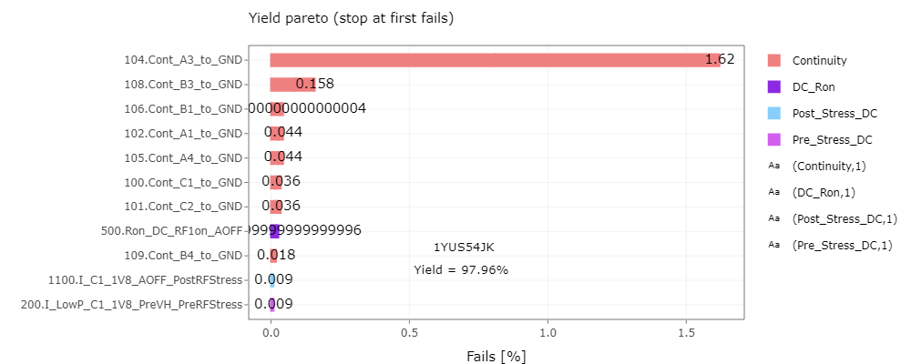

Yield Pareto by Test

### Fail count [Lot]

#### Fail count by B-Type

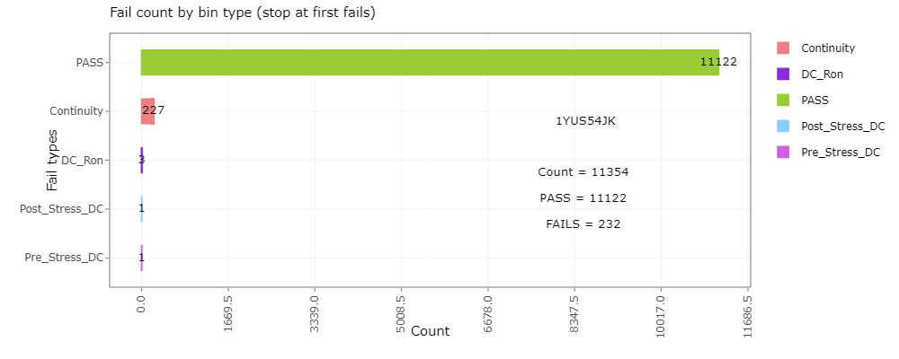

Fail count by B-Type

#### Fail count by TBIN

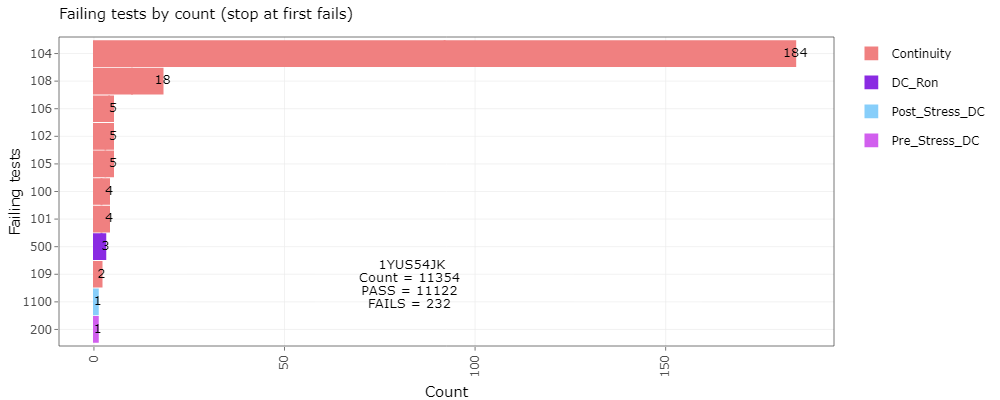

Fail count by TBIN

## Fails per Wafer [Lot]

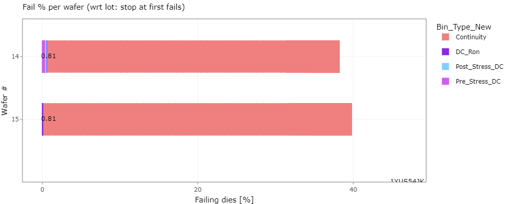

Fails per Wafer

## Cumulative yield [Lot]

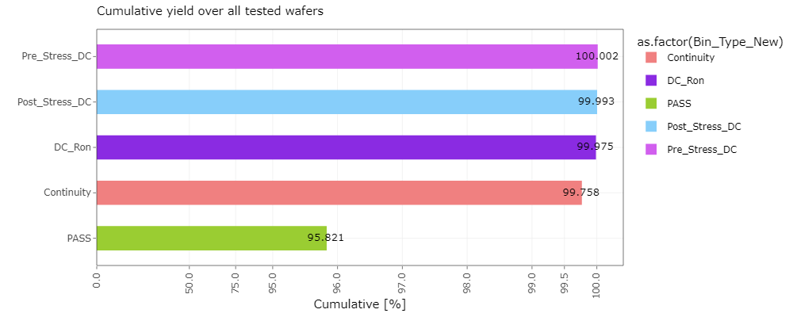

Cumulative yield

## Yield Pareto [Wafer]

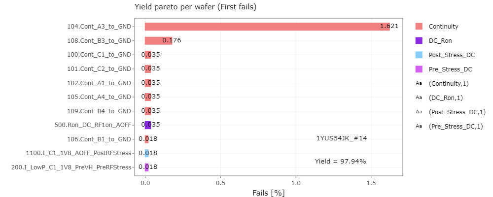

Yield Pareto [Wafer]

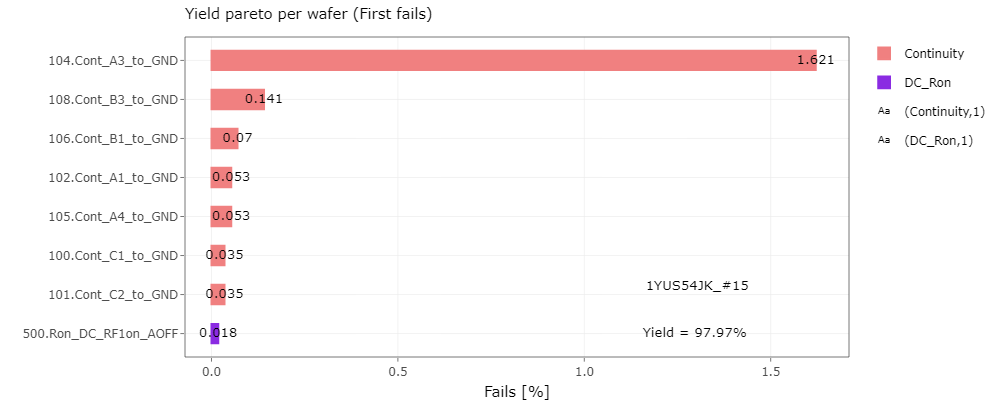

Yield Pareto [Wafer]

### Fail count [Wafer]

#### Fail count by B-Type [Wafer]

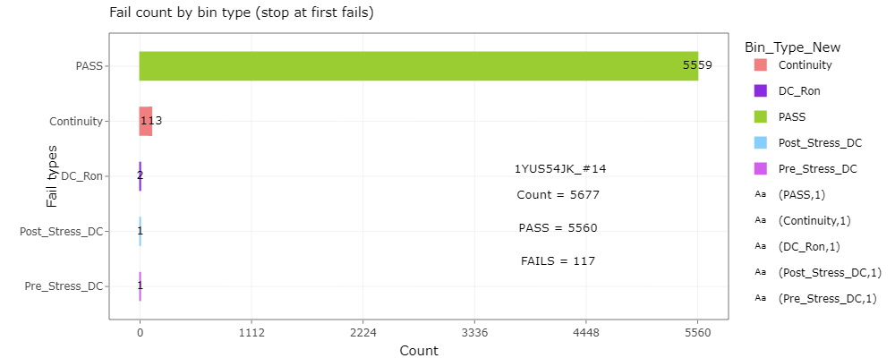

Fail count by B-Type [Wafer]

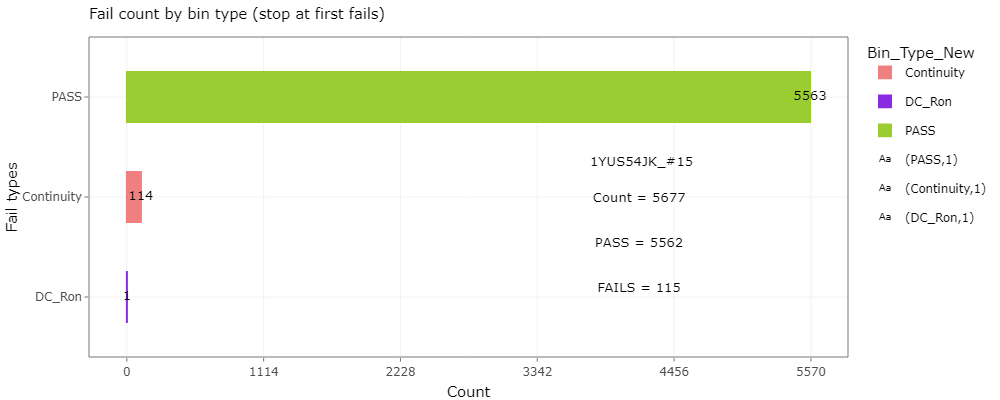

Fail count by B-Type [Wafer]

#### Fail count TBIN [Wafer]

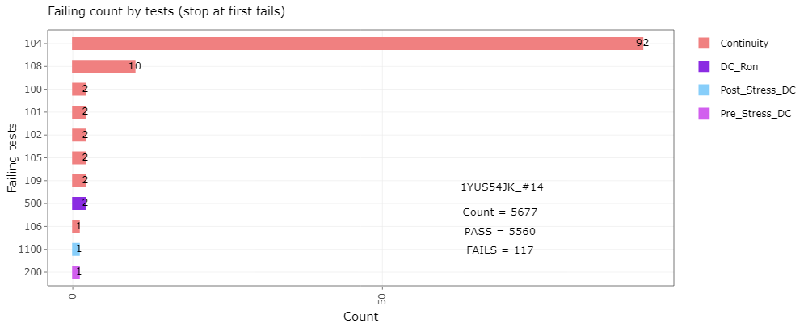

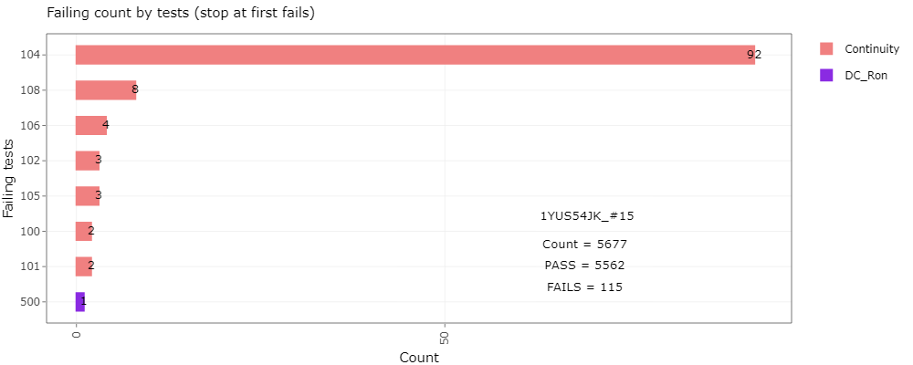

## Yield Cpk per Tests [Lot & Wafer]

### Yield_per_test_overall_LOT

| TNUM | TNAME | BIN_Nr | LSL | X.CPK2.0 | X.CPK1.67 | MIN | MEAN | MEDIAN | MAX | StD | X.CPK1.67.1 | X.CPK2.0.1 | USL | UNIT | Count | Fails | Yield | Cpk |
| --- | --- | --- | --- | --- | --- | --- | --- | --- | --- | --- | --- | --- | --- | --- | --- | --- | --- | --- |
| 1000001 | C2_Discharge | 16 | -0.1 | 162.7 | 195.2 | 0.0 | 0.0 | 0.0 | 0.0 | 0.0 | 196.4 | 163.7 | 0.1 | V | 11,354.0 | 0.0 | 100.0 | 325.4 |
| 104 | Cont_A3_to_GND | 6 | -1000 | 0.5 | 0.6 | −1,600.0 | −625.4 | −611.6 | −499.7 | 124.9 | 0.8 | 0.7 | -100 | mV | 11,354.0 | 184.0 | 98.4 | 1.0 |
| 102 | Cont_A1_to_GND | 6 | -1000 | 0.5 | 0.6 | −1,600.0 | −626.8 | −613.1 | −499.6 | 125.4 | 0.8 | 0.7 | -100 | mV | 11,170.0 | 185.0 | 98.3 | 1.0 |
| 103 | Cont_A2_to_GND | 6 | -1000 | 0.5 | 0.6 | −1,600.0 | −628.0 | −614.3 | −495.0 | 125.3 | 0.8 | 0.7 | -100 | mV | 11,169.0 | 184.0 | 98.3 | 1.0 |
| 108 | Cont_B3_to_GND | 6 | -1000 | 0.5 | 0.6 | −1,600.0 | −642.2 | −628.5 | −528.7 | 123.8 | 0.9 | 0.7 | -100 | mV | 11,170.0 | 203.0 | 98.2 | 1.0 |
| 106 | Cont_B1_to_GND | 6 | -1000 | 0.5 | 0.6 | −1,600.0 | −643.9 | −629.6 | −548.8 | 125.8 | 0.9 | 0.7 | -100 | mV | 11,151.0 | 209.0 | 98.1 | 0.9 |
| 107 | Cont_B2_to_GND | 6 | -1000 | 0.5 | 0.6 | −1,600.0 | −641.4 | −627.3 | −544.1 | 124.4 | 0.9 | 0.7 | -100 | mV | 11,145.0 | 204.0 | 98.2 | 1.0 |
| 105 | Cont_A4_to_GND | 6 | -1000 | 0.5 | 0.6 | −1,600.0 | −627.2 | −613.1 | −509.9 | 127.2 | 0.8 | 0.7 | -100 | mV | 11,150.0 | 200.0 | 98.2 | 1.0 |
| 109 | Cont_B4_to_GND | 6 | -1000 | 0.4 | 0.5 | −1,600.0 | −529.5 | −476.7 | −336.4 | 178.6 | 0.5 | 0.4 | -100 | mV | 11,154.0 | 199.0 | 98.2 | 0.8 |
| 100 | Cont_C1_to_GND | 6 | -750 | 0.8 | 0.9 | −995.4 | −340.8 | −329.2 | −0.5 | 89.7 | 0.5 | 0.4 | -100 | mV | 11,155.0 | 211.0 | 98.1 | 0.9 |
| 101 | Cont_C2_to_GND | 6 | -750 | 0.8 | 0.9 | −994.5 | −340.3 | −329.0 | −168.3 | 86.8 | 0.6 | 0.5 | -100 | mV | 11,143.0 | 210.0 | 98.1 | 0.9 |
| 200 | I_LowP_C1_1V8_PreVH_PreRFStress | 8 | 1 | 0.0 | 0.0 | 0.3 | 4.0 | 3.0 | 844.7 | 26.9 | 0.3 | 0.2 | 45 | uA | 11,144.0 | 213.0 | 98.1 | 0.0 |
| 201 | I_LowP_C1_1V95_VH_PreRFStress | 8 | 1 | 0.0 | 0.0 | 0.4 | 4.9 | 3.8 | 844.8 | 28.0 | 0.3 | 0.2 | 45 | uA | 11,141.0 | 213.0 | 98.1 | 0.0 |
| 202 | I_LowP_C1_1V8_PostVH_PreRFStress | 8 | 1 | 0.0 | 0.0 | 0.3 | 3.8 | 2.8 | 844.6 | 28.1 | 0.3 | 0.2 | 45 | uA | 11,141.0 | 213.0 | 98.1 | 0.0 |
| 203 | DELTA_I_LowP_C1_1V8_PostVH_PreRFStress | 8 | -5 | 0.2 | 0.3 | −371.9 | 0.2 | 0.3 | 3.0 | 4.0 | 0.2 | 0.2 | 5 | uA | 11,141.0 | 3.0 | 100.0 | 0.4 |
| 300 | Read_Manufacturer_ID | 7 | 26 | 0.0 | 0.0 | 1.0 | 25.5 | 26.0 | 26.0 | 3.4 | 0.0 | 0.0 | 26 | # | 11,351.0 | 221.0 | 98.0 | 0.0 |
| 302 | Read_Prod_ID | 7 | 207 | 0.0 | 0.0 | 1.0 | 203.0 | 207.0 | 207.0 | 28.5 | 0.0 | 0.0 | 207 | # | 11,133.0 | 222.0 | 98.0 | 0.0 |
| 311 | Calculate_Oscillator_freq | 7 | 77 | 0.3 | 0.4 | 0.0 | 110.0 | 111.1 | 118.1 | 15.6 | 0.6 | 0.5 | 155 | MHz | 11,132.0 | 222.0 | 98.0 | 0.7 |
| 1100 | I_C1_1V8_AOFF_PostRFStress | 15 | 10 | 0.1 | 0.1 | 0.3 | 26.8 | 25.2 | 836.8 | 28.0 | 0.7 | 0.6 | 130 | uA | 11,132.0 | 225.0 | 98.0 | 0.2 |
| 1101 | I_C1_1V8_AON_PostRFStress | 15 | 10 | 0.0 | 0.1 | 0.3 | 18.6 | 17.7 | 838.6 | 27.9 | 0.6 | 0.5 | 100 | uA | 11,129.0 | 226.0 | 98.0 | 0.1 |
| 1102 | I_C1_1V8_AOFF_PostAON_PostRFStress | 15 | 10 | 0.1 | 0.1 | 0.3 | 26.9 | 25.4 | 839.3 | 27.9 | 0.7 | 0.6 | 130 | uA | 11,128.0 | 225.0 | 98.0 | 0.2 |
| 1108 | DELTA_I_C1_1V8_AOFF_PostStress |  | -5 | 4.2 | 5.0 | −8.0 | −0.1 | −0.1 | 8.8 | 0.2 | 5.2 | 4.4 | 5 | uA | 11,129.0 | 5.0 | 100.0 | 8.3 |
| 1103 | DELTA_I_C1_1V8_AON_PrePostRFStress | 15 | -5 | 2.6 | 3.1 | −20.2 | 0.2 | 0.2 | 14.8 | 0.3 | 2.9 | 2.4 | 5 | uA | 11,349.0 | 5.0 | 100.0 | 4.8 |
| 1104 | DELTA_I_C1_1V8_AFF_PrePostRFStress | 15 | -5 | 2.5 | 3.0 | −16.5 | 0.2 | 0.2 | 18.8 | 0.3 | 2.8 | 2.3 | 5 | uA | 11,349.0 | 6.0 | 100.0 | 4.6 |
| 1105 | I_C1_1V8_RF1on_AOFF_PostRFStress | 15 | 10 | 0.1 | 0.1 | 0.3 | 24.9 | 23.5 | 839.9 | 27.8 | 0.8 | 0.6 | 130 | uA | 11,348.0 | 226.0 | 98.0 | 0.2 |
| 1106 | I_C1_1V8_RF2on_AOFF_PostRFStress | 15 | 10 | 0.1 | 0.1 | 0.3 | 24.9 | 23.5 | 840.4 | 27.8 | 0.8 | 0.6 | 130 | uA | 11,128.0 | 225.0 | 98.0 | 0.2 |
| 1107 | I_C1_1V8_RF3on_AOFF_PostRFStress | 15 | 10 | 0.1 | 0.1 | 0.3 | 24.9 | 23.5 | 841.2 | 27.8 | 0.8 | 0.6 | 130 | uA | 11,129.0 | 225.0 | 98.0 | 0.2 |
| 1113 | I_C1_1V8_RF4on_AOFF_PostRFStress |  | 10 | 0.1 | 0.1 | 0.3 | 24.9 | 23.5 | 841.3 | 27.8 | 0.8 | 0.6 | 130 | uA | 11,129.0 | 225.0 | 98.0 | 0.2 |
| 1110 | DELTA_I_C1_1V8_RF1onAOFF_PrePostRFStress | 15 | -5 | 2.6 | 3.1 | −12.2 | 0.1 | 0.1 | 18.3 | 0.3 | 3.0 | 2.5 | 5 | uA | 11,129.0 | 6.0 | 100.0 | 5.0 |
| 1111 | DELTA_I_C1_1V8_RF2onAOFF_PrePostRFStress | 15 | -5 | 2.8 | 3.4 | −9.7 | 0.1 | 0.1 | 18.0 | 0.3 | 3.2 | 2.6 | 5 | uA | 11,348.0 | 5.0 | 100.0 | 5.3 |

[output cut: 61 more lines]

### 1YUS54JK_14

| TNUM | TNAME | BIN_Nr | LSL | X.CPK2.0 | X.CPK1.67 | MIN | MEAN | MEDIAN | MAX | StD | X.CPK1.67.1 | X.CPK2.0.1 | USL | UNIT | Count | Fails | Yield | Cpk | LOT_WAFER |
| --- | --- | --- | --- | --- | --- | --- | --- | --- | --- | --- | --- | --- | --- | --- | --- | --- | --- | --- | --- |
| 1000001 | C2_Discharge | 16 | -0.1 | 164.2 | 197.1 | 0.0 | 0.0 | 0.0 | 0.0 | 0.0 | 198.4 | 165.3 | 0.1 | V | 5,676.0 | 0.0 | 100.0 | 328.5 | 1YUS54JK_14 |
| 104 | Cont_A3_to_GND | 6 | -1000 | 0.5 | 0.6 | −1,600.0 | −626.6 | −612.8 | −499.7 | 124.5 | 0.8 | 0.7 | -100 | mV | 5,676.0 | 92.0 | 98.4 | 1.0 | 1YUS54JK_14 |
| 102 | Cont_A1_to_GND | 6 | -1000 | 0.5 | 0.6 | −1,600.0 | −627.8 | −614.1 | −499.6 | 124.6 | 0.8 | 0.7 | -100 | mV | 5,584.0 | 92.0 | 98.3 | 1.0 | 1YUS54JK_14 |
| 103 | Cont_A2_to_GND | 6 | -1000 | 0.5 | 0.6 | −1,600.0 | −628.8 | −615.3 | −495.0 | 124.6 | 0.8 | 0.7 | -100 | mV | 5,584.0 | 91.0 | 98.4 | 1.0 | 1YUS54JK_14 |
| 108 | Cont_B3_to_GND | 6 | -1000 | 0.5 | 0.6 | −1,600.0 | −642.6 | −628.7 | −528.7 | 123.8 | 0.9 | 0.7 | -100 | mV | 5,585.0 | 102.0 | 98.2 | 1.0 | 1YUS54JK_14 |
| 106 | Cont_B1_to_GND | 6 | -1000 | 0.5 | 0.6 | −1,600.0 | −644.0 | −630.0 | −550.7 | 124.5 | 0.9 | 0.7 | -100 | mV | 5,574.0 | 103.0 | 98.2 | 0.9 | 1YUS54JK_14 |
| 107 | Cont_B2_to_GND | 6 | -1000 | 0.5 | 0.6 | −1,600.0 | −641.8 | −627.6 | −544.1 | 124.1 | 0.9 | 0.7 | -100 | mV | 5,573.0 | 102.0 | 98.2 | 1.0 | 1YUS54JK_14 |
| 105 | Cont_A4_to_GND | 6 | -1000 | 0.5 | 0.6 | −1,600.0 | −628.0 | −614.0 | −509.9 | 126.9 | 0.8 | 0.7 | -100 | mV | 5,574.0 | 100.0 | 98.2 | 1.0 | 1YUS54JK_14 |
| 109 | Cont_B4_to_GND | 6 | -1000 | 0.4 | 0.5 | −1,600.0 | −549.8 | −609.8 | −348.8 | 175.2 | 0.5 | 0.4 | -100 | mV | 5,576.0 | 99.0 | 98.2 | 0.9 | 1YUS54JK_14 |
| 100 | Cont_C1_to_GND | 6 | -750 | 0.8 | 0.9 | −995.4 | −340.1 | −328.8 | −0.5 | 89.9 | 0.5 | 0.4 | -100 | mV | 5,577.0 | 105.0 | 98.1 | 0.9 | 1YUS54JK_14 |
| 101 | Cont_C2_to_GND | 6 | -750 | 0.8 | 0.9 | −994.4 | −339.6 | −328.6 | −168.3 | 86.9 | 0.6 | 0.5 | -100 | mV | 5,571.0 | 105.0 | 98.1 | 0.9 | 1YUS54JK_14 |
| 200 | I_LowP_C1_1V8_PreVH_PreRFStress | 8 | 1 | 0.0 | 0.0 | 0.3 | 3.9 | 3.1 | 844.7 | 23.3 | 0.3 | 0.3 | 45 | uA | 5,571.0 | 105.0 | 98.1 | 0.0 | 1YUS54JK_14 |
| 201 | I_LowP_C1_1V95_VH_PreRFStress | 8 | 1 | 0.0 | 0.0 | 0.4 | 4.8 | 3.9 | 844.8 | 25.0 | 0.3 | 0.3 | 45 | uA | 5,571.0 | 105.0 | 98.1 | 0.0 | 1YUS54JK_14 |
| 202 | I_LowP_C1_1V8_PostVH_PreRFStress | 8 | 1 | 0.0 | 0.0 | 0.3 | 3.7 | 2.8 | 844.6 | 25.0 | 0.3 | 0.3 | 45 | uA | 5,571.0 | 105.0 | 98.1 | 0.0 | 1YUS54JK_14 |
| 203 | DELTA_I_LowP_C1_1V8_PostVH_PreRFStress | 8 | -5 | 0.2 | 0.2 | −371.9 | 0.2 | 0.3 | 0.6 | 5.0 | 0.2 | 0.2 | 5 | uA | 5,571.0 | 2.0 | 100.0 | 0.3 | 1YUS54JK_14 |
| 300 | Read_Manufacturer_ID | 7 | 26 | 0.0 | 0.0 | 1.0 | 25.5 | 26.0 | 26.0 | 3.4 | 0.0 | 0.0 | 26 | # | 5,674.0 | 110.0 | 98.1 | 0.0 | 1YUS54JK_14 |
| 302 | Read_Prod_ID | 7 | 207 | 0.0 | 0.0 | 1.0 | 203.0 | 207.0 | 207.0 | 28.5 | 0.0 | 0.0 | 207 | # | 5,566.0 | 111.0 | 98.0 | 0.0 | 1YUS54JK_14 |
| 311 | Calculate_Oscillator_freq | 7 | 77 | 0.3 | 0.4 | 0.0 | 110.1 | 113.4 | 118.1 | 15.7 | 0.6 | 0.5 | 155 | MHz | 5,565.0 | 111.0 | 98.0 | 0.7 | 1YUS54JK_14 |
| 1100 | I_C1_1V8_AOFF_PostRFStress | 15 | 10 | 0.1 | 0.1 | 0.3 | 29.0 | 28.1 | 836.8 | 25.0 | 0.8 | 0.7 | 130 | uA | 5,565.0 | 112.0 | 98.0 | 0.2 | 1YUS54JK_14 |
| 1101 | I_C1_1V8_AON_PostRFStress | 15 | 10 | 0.1 | 0.1 | 0.3 | 18.8 | 18.1 | 838.6 | 24.8 | 0.6 | 0.6 | 100 | uA | 5,564.0 | 112.0 | 98.0 | 0.1 | 1YUS54JK_14 |
| 1102 | I_C1_1V8_AOFF_PostAON_PostRFStress | 15 | 10 | 0.1 | 0.1 | 0.3 | 29.2 | 28.3 | 839.3 | 25.0 | 0.8 | 0.7 | 130 | uA | 5,564.0 | 112.0 | 98.0 | 0.3 | 1YUS54JK_14 |
| 1108 | DELTA_I_C1_1V8_AOFF_PostStress |  | -5 | 4.2 | 5.0 | −8.0 | −0.1 | −0.1 | 8.8 | 0.2 | 5.2 | 4.4 | 5 | uA | 5,564.0 | 2.0 | 100.0 | 8.3 | 1YUS54JK_14 |
| 1103 | DELTA_I_C1_1V8_AON_PrePostRFStress | 15 | -5 | 5.8 | 6.9 | −0.9 | 0.2 | 0.1 | 5.0 | 0.1 | 6.5 | 5.4 | 5 | uA | 5,674.0 | 0.0 | 100.0 | 10.9 | 1YUS54JK_14 |
| 1104 | DELTA_I_C1_1V8_AFF_PrePostRFStress | 15 | -5 | 5.7 | 6.8 | −0.9 | 0.1 | 0.1 | 4.4 | 0.1 | 6.4 | 5.4 | 5 | uA | 5,676.0 | 0.0 | 100.0 | 10.7 | 1YUS54JK_14 |
| 1105 | I_C1_1V8_RF1on_AOFF_PostRFStress | 15 | 10 | 0.1 | 0.1 | 0.3 | 26.6 | 25.8 | 839.9 | 24.8 | 0.8 | 0.7 | 130 | uA | 5,676.0 | 112.0 | 98.0 | 0.2 | 1YUS54JK_14 |
| 1106 | I_C1_1V8_RF2on_AOFF_PostRFStress | 15 | 10 | 0.1 | 0.1 | 0.3 | 26.6 | 25.8 | 840.4 | 24.8 | 0.8 | 0.7 | 130 | uA | 5,564.0 | 112.0 | 98.0 | 0.2 | 1YUS54JK_14 |
| 1107 | I_C1_1V8_RF3on_AOFF_PostRFStress | 15 | 10 | 0.1 | 0.1 | 0.3 | 26.6 | 25.8 | 841.2 | 24.9 | 0.8 | 0.7 | 130 | uA | 5,564.0 | 112.0 | 98.0 | 0.2 | 1YUS54JK_14 |
| 1113 | I_C1_1V8_RF4on_AOFF_PostRFStress |  | 10 | 0.1 | 0.1 | 0.3 | 26.6 | 25.8 | 841.3 | 24.9 | 0.8 | 0.7 | 130 | uA | 5,564.0 | 112.0 | 98.0 | 0.2 | 1YUS54JK_14 |
| 1110 | DELTA_I_C1_1V8_RF1onAOFF_PrePostRFStress | 15 | -5 | 5.9 | 7.0 | −0.7 | 0.1 | 0.1 | 3.8 | 0.1 | 6.8 | 5.6 | 5 | uA | 5,564.0 | 0.0 | 100.0 | 11.2 | 1YUS54JK_14 |
| 1111 | DELTA_I_C1_1V8_RF2onAOFF_PrePostRFStress | 15 | -5 | 6.2 | 7.4 | −0.7 | 0.1 | 0.1 | 3.6 | 0.1 | 7.0 | 5.9 | 5 | uA | 5,676.0 | 0.0 | 100.0 | 11.8 | 1YUS54JK_14 |

[output cut: 61 more lines]

### 1YUS54JK_15

| TNUM | TNAME | BIN_Nr | LSL | X.CPK2.0 | X.CPK1.67 | MIN | MEAN | MEDIAN | MAX | StD | X.CPK1.67.1 | X.CPK2.0.1 | USL | UNIT | Count | Fails | Yield | Cpk | LOT_WAFER |
| --- | --- | --- | --- | --- | --- | --- | --- | --- | --- | --- | --- | --- | --- | --- | --- | --- | --- | --- | --- |
| 1000001 | C2_Discharge | 16 | -0.1 | 172.9 | 207.4 | 0.0 | 0.0 | 0.0 | 0.0 | 0.0 | 208.6 | 173.8 | 0.1 | V | 5,678.0 | 0.0 | 100.0 | 345.7 | 1YUS54JK_15 |
| 104 | Cont_A3_to_GND | 6 | -1000 | 0.5 | 0.6 | −1,600.0 | −624.1 | −610.3 | −536.1 | 125.4 | 0.8 | 0.7 | -100 | mV | 5,678.0 | 92.0 | 98.4 | 1.0 | 1YUS54JK_15 |
| 102 | Cont_A1_to_GND | 6 | -1000 | 0.5 | 0.6 | −1,600.0 | −625.8 | −611.9 | −525.5 | 126.1 | 0.8 | 0.7 | -100 | mV | 5,586.0 | 93.0 | 98.3 | 1.0 | 1YUS54JK_15 |
| 103 | Cont_A2_to_GND | 6 | -1000 | 0.5 | 0.6 | −1,600.0 | −627.1 | −613.4 | −516.9 | 126.0 | 0.8 | 0.7 | -100 | mV | 5,585.0 | 93.0 | 98.3 | 1.0 | 1YUS54JK_15 |
| 108 | Cont_B3_to_GND | 6 | -1000 | 0.5 | 0.6 | −1,600.0 | −641.8 | −628.3 | −554.1 | 123.8 | 0.9 | 0.7 | -100 | mV | 5,585.0 | 101.0 | 98.2 | 1.0 | 1YUS54JK_15 |
| 106 | Cont_B1_to_GND | 6 | -1000 | 0.5 | 0.6 | −1,600.0 | −643.7 | −629.3 | −548.8 | 127.1 | 0.9 | 0.7 | -100 | mV | 5,577.0 | 106.0 | 98.1 | 0.9 | 1YUS54JK_15 |
| 107 | Cont_B2_to_GND | 6 | -1000 | 0.5 | 0.6 | −1,600.0 | −641.1 | −627.1 | −550.3 | 124.8 | 0.9 | 0.7 | -100 | mV | 5,572.0 | 102.0 | 98.2 | 1.0 | 1YUS54JK_15 |
| 105 | Cont_A4_to_GND | 6 | -1000 | 0.5 | 0.6 | −1,600.0 | −626.4 | −612.3 | −534.4 | 127.5 | 0.8 | 0.7 | -100 | mV | 5,576.0 | 100.0 | 98.2 | 1.0 | 1YUS54JK_15 |
| 109 | Cont_B4_to_GND | 6 | -1000 | 0.5 | 0.6 | −1,600.0 | −509.2 | −417.6 | −336.4 | 179.7 | 0.5 | 0.4 | -100 | mV | 5,578.0 | 100.0 | 98.2 | 0.8 | 1YUS54JK_15 |
| 100 | Cont_C1_to_GND | 6 | -750 | 0.8 | 0.9 | −995.4 | −341.5 | −329.9 | −1.6 | 89.5 | 0.5 | 0.4 | -100 | mV | 5,578.0 | 106.0 | 98.1 | 0.9 | 1YUS54JK_15 |
| 101 | Cont_C2_to_GND | 6 | -750 | 0.8 | 0.9 | −994.5 | −340.9 | −329.6 | −313.6 | 86.7 | 0.6 | 0.5 | -100 | mV | 5,572.0 | 105.0 | 98.1 | 0.9 | 1YUS54JK_15 |
| 200 | I_LowP_C1_1V8_PreVH_PreRFStress | 8 | 1 | 0.0 | 0.0 | 0.3 | 4.2 | 3.0 | 844.3 | 30.1 | 0.3 | 0.2 | 45 | uA | 5,573.0 | 108.0 | 98.1 | 0.0 | 1YUS54JK_15 |
| 201 | I_LowP_C1_1V95_VH_PreRFStress | 8 | 1 | 0.0 | 0.0 | 0.4 | 5.0 | 3.7 | 844.2 | 30.8 | 0.3 | 0.2 | 45 | uA | 5,570.0 | 108.0 | 98.1 | 0.0 | 1YUS54JK_15 |
| 202 | I_LowP_C1_1V8_PostVH_PreRFStress | 8 | 1 | 0.0 | 0.0 | 0.3 | 4.0 | 2.7 | 844.3 | 30.8 | 0.3 | 0.2 | 45 | uA | 5,570.0 | 108.0 | 98.1 | 0.0 | 1YUS54JK_15 |
| 203 | DELTA_I_LowP_C1_1V8_PostVH_PreRFStress | 8 | -5 | 0.3 | 0.4 | −194.2 | 0.2 | 0.3 | 3.0 | 2.6 | 0.4 | 0.3 | 5 | uA | 5,570.0 | 1.0 | 100.0 | 0.6 | 1YUS54JK_15 |
| 300 | Read_Manufacturer_ID | 7 | 26 | 0.0 | 0.0 | 1.0 | 25.5 | 26.0 | 26.0 | 3.5 | 0.0 | 0.0 | 26 | # | 5,677.0 | 111.0 | 98.0 | 0.0 | 1YUS54JK_15 |
| 302 | Read_Prod_ID | 7 | 207 | 0.0 | 0.0 | 1.0 | 203.0 | 207.0 | 207.0 | 28.5 | 0.0 | 0.0 | 207 | # | 5,567.0 | 111.0 | 98.0 | 0.0 | 1YUS54JK_15 |
| 311 | Calculate_Oscillator_freq | 7 | 77 | 0.3 | 0.4 | 0.0 | 109.8 | 111.1 | 115.7 | 15.6 | 0.6 | 0.5 | 155 | MHz | 5,567.0 | 111.0 | 98.0 | 0.7 | 1YUS54JK_15 |
| 1100 | I_C1_1V8_AOFF_PostRFStress | 15 | 10 | 0.1 | 0.1 | 0.3 | 24.6 | 23.4 | 836.0 | 30.6 | 0.7 | 0.6 | 130 | uA | 5,567.0 | 113.0 | 98.0 | 0.2 | 1YUS54JK_15 |
| 1101 | I_C1_1V8_AON_PostRFStress | 15 | 10 | 0.0 | 0.0 | 0.3 | 18.3 | 17.3 | 833.8 | 30.6 | 0.5 | 0.4 | 100 | uA | 5,565.0 | 114.0 | 98.0 | 0.1 | 1YUS54JK_15 |
| 1102 | I_C1_1V8_AOFF_PostAON_PostRFStress | 15 | 10 | 0.1 | 0.1 | 0.3 | 24.8 | 23.4 | 829.8 | 30.5 | 0.7 | 0.6 | 130 | uA | 5,564.0 | 113.0 | 98.0 | 0.2 | 1YUS54JK_15 |
| 1108 | DELTA_I_C1_1V8_AOFF_PostStress |  | -5 | 4.2 | 5.0 | −3.1 | −0.1 | −0.1 | 8.0 | 0.2 | 5.2 | 4.4 | 5 | uA | 5,565.0 | 3.0 | 100.0 | 8.4 | 1YUS54JK_15 |
| 1103 | DELTA_I_C1_1V8_AON_PrePostRFStress | 15 | -5 | 1.9 | 2.3 | −20.2 | 0.2 | 0.2 | 14.8 | 0.4 | 2.2 | 1.8 | 5 | uA | 5,675.0 | 5.0 | 99.9 | 3.6 | 1YUS54JK_15 |
| 1104 | DELTA_I_C1_1V8_AFF_PrePostRFStress | 15 | -5 | 1.8 | 2.2 | −16.5 | 0.2 | 0.2 | 18.8 | 0.5 | 2.0 | 1.7 | 5 | uA | 5,673.0 | 6.0 | 99.9 | 3.4 | 1YUS54JK_15 |
| 1105 | I_C1_1V8_RF1on_AOFF_PostRFStress | 15 | 10 | 0.1 | 0.1 | 0.3 | 23.2 | 22.0 | 825.5 | 30.4 | 0.7 | 0.6 | 130 | uA | 5,672.0 | 114.0 | 98.0 | 0.1 | 1YUS54JK_15 |
| 1106 | I_C1_1V8_RF2on_AOFF_PostRFStress | 15 | 10 | 0.1 | 0.1 | 0.3 | 23.2 | 21.9 | 823.1 | 30.4 | 0.7 | 0.6 | 130 | uA | 5,564.0 | 113.0 | 98.0 | 0.1 | 1YUS54JK_15 |
| 1107 | I_C1_1V8_RF3on_AOFF_PostRFStress | 15 | 10 | 0.1 | 0.1 | 0.3 | 23.2 | 21.9 | 821.5 | 30.4 | 0.7 | 0.6 | 130 | uA | 5,565.0 | 113.0 | 98.0 | 0.1 | 1YUS54JK_15 |
| 1113 | I_C1_1V8_RF4on_AOFF_PostRFStress |  | 10 | 0.1 | 0.1 | 0.3 | 23.2 | 21.9 | 820.5 | 30.4 | 0.7 | 0.6 | 130 | uA | 5,565.0 | 113.0 | 98.0 | 0.1 | 1YUS54JK_15 |
| 1110 | DELTA_I_C1_1V8_RF1onAOFF_PrePostRFStress | 15 | -5 | 2.0 | 2.4 | −12.2 | 0.1 | 0.1 | 18.3 | 0.4 | 2.2 | 1.9 | 5 | uA | 5,565.0 | 6.0 | 99.9 | 3.7 | 1YUS54JK_15 |
| 1111 | DELTA_I_C1_1V8_RF2onAOFF_PrePostRFStress | 15 | -5 | 2.1 | 2.5 | −9.7 | 0.1 | 0.1 | 18.0 | 0.4 | 2.4 | 2.0 | 5 | uA | 5,672.0 | 5.0 | 99.9 | 4.0 | 1YUS54JK_15 |

[output cut: 61 more lines]

# Parametric Plots

## Histogram

### 104.Cont_A3_to_GND

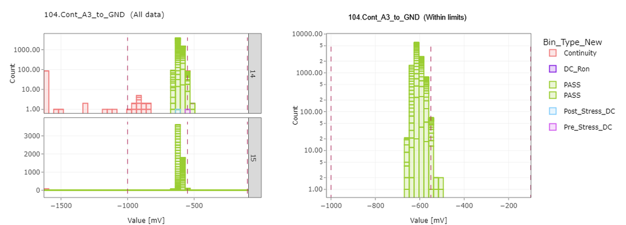

104_RangeP1_All data_LOT_1YUS54JK_WAFER_14_15_GROUP_Bin_Type_New_SPLIT_TRUE_WAFER._FALSE_RangeP2_Within limits_104.png

108.Cont_B3_to_GND (No image available or redundant image)

102.Cont_A1_to_GND (No image available or redundant image)

106.Cont_B1_to_GND (No image available or redundant image)

105.Cont_A4_to_GND (No image available or redundant image)

100.Cont_C1_to_GND (No image available or redundant image)

101.Cont_C2_to_GND (No image available or redundant image)

500.Ron_DC_RF1on_AOFF (No image available or redundant image)

109.Cont_B4_to_GND (No image available or redundant image)

200.I_LowP_C1_1V8_PreVH_PreRFStress (No image available or redundant image)

### 1100.I_C1_1V8_AOFF_PostRFStress

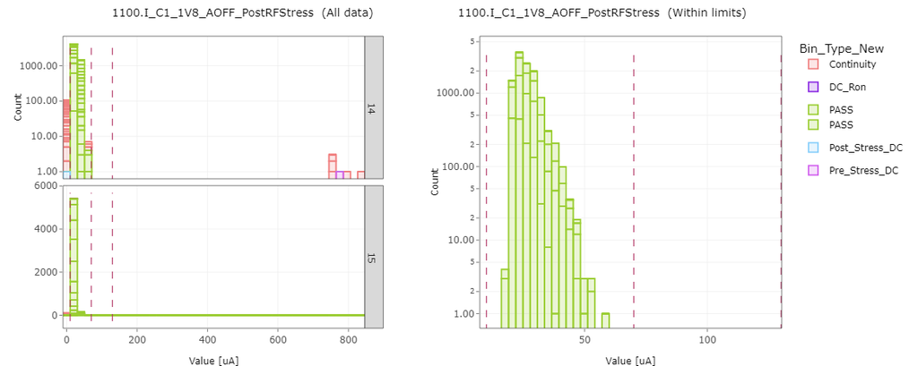

1100_RangeP1_All data_LOT_1YUS54JK_WAFER_14_15_GROUP_Bin_Type_New_SPLIT_TRUE_WAFER._FALSE_RangeP2_Within limits_1100.png

1100.I_C1_1V8_AOFF_PostRFStress (No image available or redundant image)

## Wafer-map

### 104.Cont_A3_to_GND

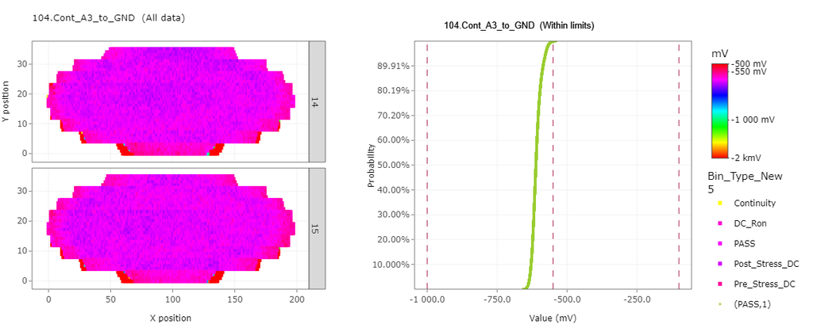

104_RangeP1_All data_LOT_1YUS54JK_WAFER_14_15_GROUP_Bin_Type_New_SPLIT_TRUE_WAFER._FALSE_RangeP2_Within limits_104.png

104.Cont_A3_to_GND (No image available or redundant image)

108.Cont_B3_to_GND (No image available or redundant image)

102.Cont_A1_to_GND (No image available or redundant image)

106.Cont_B1_to_GND (No image available or redundant image)

105.Cont_A4_to_GND (No image available or redundant image)

100.Cont_C1_to_GND (No image available or redundant image)

101.Cont_C2_to_GND (No image available or redundant image)

### 500.Ron_DC_RF1on_AOFF

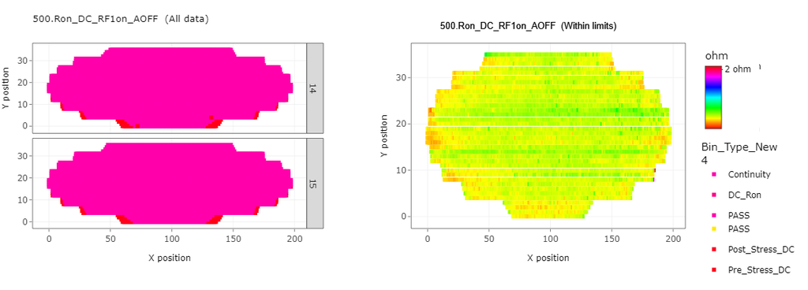

500_RangeP1_All data_LOT_1YUS54JK_WAFER_14_15_GROUP_Bin_Type_New_SPLIT_TRUE_WAFER._FALSE_RangeP2_Within limits_500.png

500.Ron_DC_RF1on_AOFF (No image available or redundant image)

109.Cont_B4_to_GND (No image available or redundant image)

200.I_LowP_C1_1V8_PreVH_PreRFStress (No image available or redundant image)

### 1100.I_C1_1V8_AOFF_PostRFStress

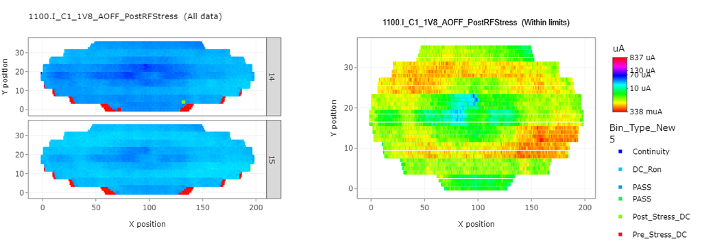

1100_RangeP1_All data_LOT_1YUS54JK_WAFER_14_15_GROUP_Bin_Type_New_SPLIT_TRUE_WAFER._FALSE_RangeP2_Within limits_1100.png

1100.I_C1_1V8_AOFF_PostRFStress (No image available or redundant image)

## Bin_Wafer-map

### 104.Cont_A3_to_GND

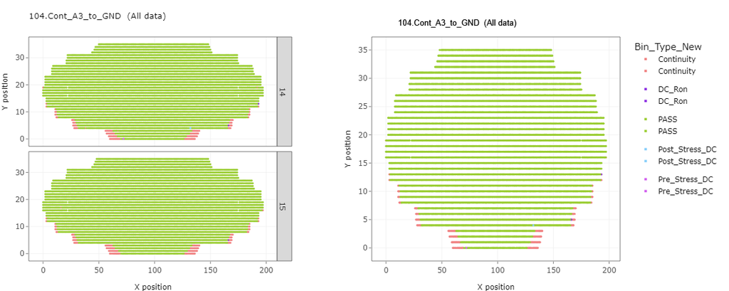

104_RangeP1_All data_LOT_1YUS54JK_WAFER_14_15_GROUP_Bin_Type_New_SPLIT_TRUE_WAFER._FALSE_RangeP2_All data_104.png

104.Cont_A3_to_GND (No image available or redundant image)

108.Cont_B3_to_GND (No image available or redundant image)

102.Cont_A1_to_GND (No image available or redundant image)

106.Cont_B1_to_GND (No image available or redundant image)

105.Cont_A4_to_GND (No image available or redundant image)

100.Cont_C1_to_GND (No image available or redundant image)

101.Cont_C2_to_GND (No image available or redundant image)

500.Ron_DC_RF1on_AOFF (No image available or redundant image)

109.Cont_B4_to_GND (No image available or redundant image)

200.I_LowP_C1_1V8_PreVH_PreRFStress (No image available or redundant image)

1100.I_C1_1V8_AOFF_PostRFStress (No image available or redundant image)

## Cumulative probability

### 104.Cont_A3_to_GND

[figure not shown]

104_RangeP1_All data_LOT_1YUS54JK_WAFER_14_15_GROUP_Bin_Type_New_SPLIT_TRUE_WAFER._FALSE_RangeP2_Within limits_104.png

104.Cont_A3_to_GND (No image available or redundant image)

108.Cont_B3_to_GND (No image available or redundant image)

102.Cont_A1_to_GND (No image available or redundant image)

106.Cont_B1_to_GND (No image available or redundant image)

105.Cont_A4_to_GND (No image available or redundant image)

100.Cont_C1_to_GND (No image available or redundant image)

101.Cont_C2_to_GND (No image available or redundant image)

500.Ron_DC_RF1on_AOFF (No image available or redundant image)

109.Cont_B4_to_GND (No image available or redundant image)

200.I_LowP_C1_1V8_PreVH_PreRFStress (No image available or redundant image)

### 1100.I_C1_1V8_AOFF_PostRFStress

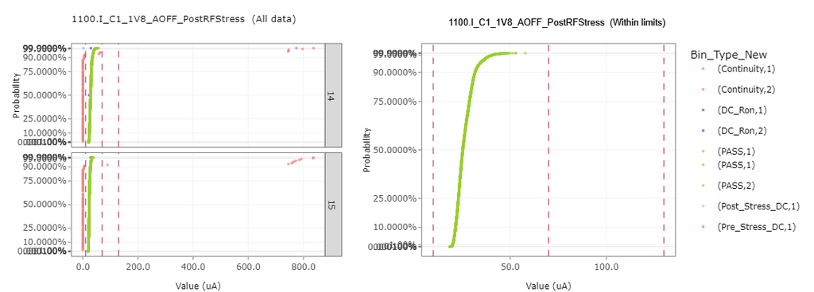

1100_RangeP1_All data_LOT_1YUS54JK_WAFER_14_15_GROUP_Bin_Type_New_SPLIT_TRUE_WAFER._FALSE_RangeP2_Within limits_1100.png

1100.I_C1_1V8_AOFF_PostRFStress (No image available or redundant image)

## Scatter plot

### 104.Cont_A3_to_GND

[figure not shown]

104_RangeP1_All data_LOT_1YUS54JK_WAFER_14_15_GROUP_Bin_Type_New_SPLIT_TRUE_WAFER._FALSE_RangeP2_Within limits_104.png

104.Cont_A3_to_GND (No image available or redundant image)

108.Cont_B3_to_GND (No image available or redundant image)

102.Cont_A1_to_GND (No image available or redundant image)

106.Cont_B1_to_GND (No image available or redundant image)

105.Cont_A4_to_GND (No image available or redundant image)

100.Cont_C1_to_GND (No image available or redundant image)

101.Cont_C2_to_GND (No image available or redundant image)

500.Ron_DC_RF1on_AOFF (No image available or redundant image)

109.Cont_B4_to_GND (No image available or redundant image)

200.I_LowP_C1_1V8_PreVH_PreRFStress (No image available or redundant image)

1100.I_C1_1V8_AOFF_PostRFStress (No image available or redundant image)